# Coursework Report

*N* removed NAs: 2

*N* removed typo: 1

*N* removed <18: 22

*N* total clean: 125

| Group | *N* | *M*<sub>age</sub> | *M*<sub>rating</sub> |
| --- | --- | --- | --- |
| Control | 60 | 21.18 | 6.94 |
| Experim | 65 | 20.83 | 6.15 |

**Main analysis results**

*t*(123) = 6.06, *p* < .001

[interactive chart not shown]

[figure not shown]

[interactive chart not shown]

# Coursework Report

Analysing Data, Spring 2020

# Methods

## Participants

Originally there were 150 participants in the experiment. Two were removed because they didn’t provide an age, making their data sets incomplete. We removed the participants for this reason because without ages for every participant we would not be able to accurately conduct a statistical analysis. A further 22 participants were removed from the data set because their ages were under the age of 18, therefore it was unethical to use their data in the experiment. 1 row of data was also removed because there was a typo in the age value, meaning that we could not be sure that the individual was 18 years or older. Because of these reasons, the final numer of participants whose data was included in the results was 125, 65 in the experimental condition and 60 in the control condition. The mean participant age is 21. The standard deviation of the participant ages is 2.27. The ages of the participants ranged from 18 to 29, making the range 11.

Table 1 *Descriptive statistics for age by condition*

[output not shown]

## Design

The conceptual hypothesis for this experiment is: *Does colour influence attraction?*

The operational hypothesis for this experiment is: *The participants in the experimental condition will provide a higher rating of attractiveness towards the man in the photograph on a scale of 1-9 than the participants in the control group.*

Each participants were shown a black and white 6x4 inch photo of a male’s head and upper torso. The participants were divided into two groups: the control group and the experimental group. The control group were shown the photo of the man in a white frame, and the experimental group were shown the photo in a red frame. This makes the condition variable of the experiment the factor variable as it is the independant variable. The participants were then asked 3 questions to which they provided an answer in the form of a rating on a scale of 1-9. 1 is the lowest score, meaning little attraction. 9 is the highest score, meaning high attraction. Each question is represented as an item in the data set. Question 1 is ‘item 1’, question 2 is ‘item 2’, and question 3 is ‘item 3’. The 3 questions the participants were asked were: “how attractive do you think this person is?”, “how pleasant is this person to look at?”, and “if I were to meet the person in the picture face to face I would think he is attractive.” (Elliot et al, 2010). The ratings for each item were averaged for each participant to find the overall rating of attractiveness. This study is an independent measures design, because each group completed different conditions.

# Results

First, the composite scores for each participant were calculated and summarised in a table

*Table 2. Composite Attraction Scores*

| Condition | N | % | Mean Age | Mean Score |
| --- | --- | --- | --- | --- |
| control | 60 | 48 | 21.18 | 6.94 |
| experimental | 65 | 52 | 20.83 | 6.15 |

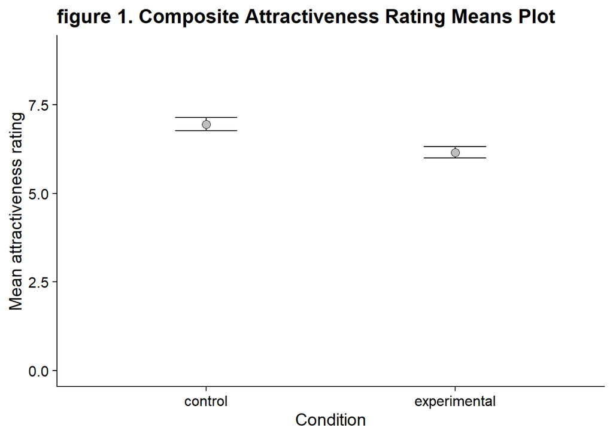

From this plot we can see that the mean of the control group is significantly higher than the experimental group. We can also see that the error bars do not overlap, meaning that there is a significant difference between the two means. To further analyse this data a T-test was used.

```
##
##  Two Sample t-test
##
## data:  composite_score by condition
## t = 6.0625, df = 123, p-value = 0.00000001517
## alternative hypothesis: true difference in means is not equal to 0
## 95 percent confidence interval:
##  0.5287232 1.0413622
## sample estimates:
##      mean in group control mean in group experimental
##                   6.938889                   6.153846
```

# Discussion

A future study to test the red effect should include a larger age range of participants. It should also include a pre-test questionnaire which asks questions about the individual’s sexual orientation, race and ethnicity, which can all impact preference of attractiveness. This would make the study more generalisable to the whole population, therefore increase its ecological validity. As well as this, to make the results more accurate, unconscious responses should be measured such as heart rate and pupil dilation. This way the participants cannot deceive us in their responses. The study should also test the red effect not only on women’s perception of attraction towards men, but also vice versa. This would make the results generalisable across genders.

Another suggestion for a follow up study would be to test the hypothesis that the colour red is associated with anger and threat, and that the colour white is associated with purity, innocence and kindness. This would provide an alternative hypothesis to ‘the red effect’, as well as provide more explanation as to why the control group in our study and Peperkoorn et al’s study had a higher composite score for the photo with a white frame.

In conclusion, the results from original study (Elliot et al., 2010) and our study have shown that the results are not replicable and therefore that the hypothesis that there is a strong positive correlation between the presence of the colour red and perceived attractiveness is incorrect. The results from our study, as well as from other studies, imply that colours do have an impact on perceived attraction, however more studies need to be conducted to provide sufficient evidence for this hypothesis.

# References

Elliot, A. J., Niesta Kayser, D., Greitemeyer, T., Lichtenfeld, S., Gramzow, R. H., Maier, M. A., & Liu, H. (2010). Red, Rank, and Romance in women viewing men. Journal of Experimental Psychology: General. https://doi.org/10.1037/a0019689

Peperkoorn, L. S., Roberts, S. C., & Pollet, T. V. (2016). Revisiting the red effect on attractiveness and sexual receptivity: No effect of the color red on human mate preferences. Evolutionary Psychology. https://doi.org/10.1177/1474704916673841

Wiedemann, D., Burt, D. M., Hill, R. A., & Barton, R. A. (2015). Red clothing increases perceived dominance, aggression and anger. Biology Letters. https://doi.org/10.1098/rsbl.2015.0166